# PROYECTO 1

```python
df["Producto"]
```

```
0        Impresora
1            Mouse
2           Laptop
3       Cámara Web
4          Teclado
          ...
995        Monitor
996         Laptop
997    Memoria RAM
998    Memoria RAM
999        Monitor
Name: Producto, Length: 1000, dtype: object
```

```python
productos = df["Producto"].value_counts().head(10)

productos
```

```
Producto
Teclado          171
Mouse            170
Laptop           136
Monitor          129
PC Escritorio     89
Disco SSD         89
Memoria RAM       70
Impresora         59
Router            49
Cámara Web        38
Name: count, dtype: int64
```

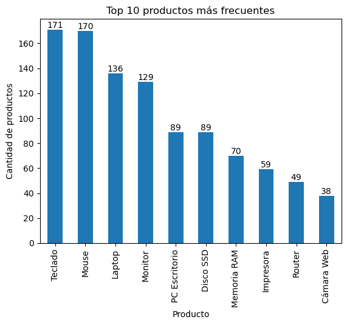

```python
ax = productos.plot(
    kind="bar",
    title="Top 10 productos más frecuentes",
    xlabel="Producto",
    ylabel="Cantidad de productos"
)

ax.bar_label(ax.containers[0]);
```

```python
df["Producto"].value_counts()
```

```
Producto
Teclado          171
Mouse            170
Laptop           136
Monitor          129
PC Escritorio     89
Disco SSD         89
Memoria RAM       70
Impresora         59
Router            49
Cámara Web        38
Name: count, dtype: int64
```

```python
df.head()
```

|  | ID | Producto | Categoría |
| --- | --- | --- | --- |
| 0 | 1 | Impresora | Impresión |
| 1 | 2 | Mouse | Perifericos |
| 2 | 3 | Laptop | Computadores |
| 3 | 4 | Cámara Web | Perifericos |
| 4 | 5 | Teclado | Perifericos |

```python
productos = df["Producto"].value_counts().head(10)

productos
```

```
Producto
Teclado          171
Mouse            170
Laptop           136
Monitor          129
PC Escritorio     89
Disco SSD         89
Memoria RAM       70
Impresora         59
Router            49
Cámara Web        38
Name: count, dtype: int64
```

```python
porcentaje_productos = df["Producto"].value_counts(normalize=True) * 100

porcentaje_productos.head(10)
```

```
Producto
Teclado          17.1
Mouse            17.0
Laptop           13.6
Monitor          12.9
PC Escritorio     8.9
Disco SSD         8.9
Memoria RAM       7.0
Impresora         5.9
Router            4.9
Cámara Web        3.8
Name: proportion, dtype: float64
```

```python
producto_mas_frecuente = df["Producto"].value_counts().iloc[0]
total_productos = len(df)

porcentaje = (producto_mas_frecuente / total_productos) * 100

porcentaje
```

```
np.float64(17.1)
```

```python
producto_top_categoria = (
    df.groupby("Categoría")["Producto"]
    .value_counts()
    .groupby(level=0)
    .head(1)
)

producto_top_categoria
```

```
Categoría       Producto
Almacenamiento  Disco SSD       89
Componentes     Memoria RAM     70
Computadores    Laptop         136
Impresión       Impresora       59
Perifericos     Teclado        171
Redes           Router          49
Name: count, dtype: int64
```

```python
df.groupby("Categoría")["Producto"].value_counts()
```

```
Categoría       Producto
Almacenamiento  Disco SSD         89
Componentes     Memoria RAM       70
Computadores    Laptop           136
                PC Escritorio     89
Impresión       Impresora         59
Perifericos     Teclado          171
                Mouse            170
                Monitor          129
                Cámara Web        38
Redes           Router            49
Name: count, dtype: int64
```

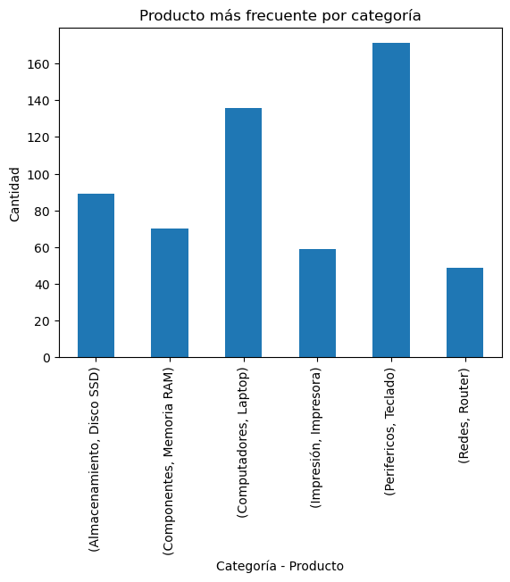

```python
producto_top_categoria.plot(
    kind="bar",
    title="Producto más frecuente por categoría",
    xlabel="Categoría - Producto",
    ylabel="Cantidad"
)
```

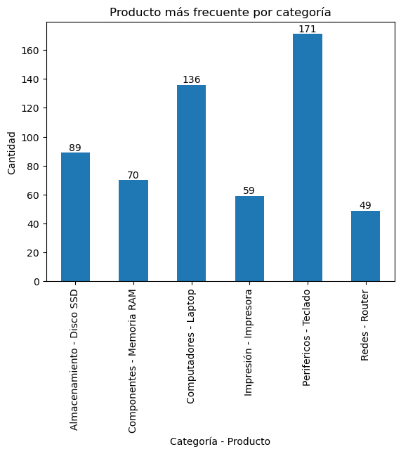

```python
top_categoria = producto_top_categoria.reset_index()

top_categoria["Etiqueta"] = (
    top_categoria["Categoría"] + " - " + top_categoria["Producto"]
)

ax = top_categoria.plot(
    x="Etiqueta",
    y="count",
    kind="bar",
    title="Producto más frecuente por categoría",
    xlabel="Categoría - Producto",
    ylabel="Cantidad",
    legend=False
)

ax.bar_label(ax.containers[0]);
```

```python
df.isnull().sum()
```

```
ID           0
Producto     0
Categoría    0
dtype: int64
```

```python
df.duplicated().sum()
```

```
np.int64(0)
```

```python
df["Producto"].unique()
```

```
array(['Impresora', 'Mouse', 'Laptop', 'Cámara Web', 'Teclado', 'Monitor',
       'Router', 'PC Escritorio', 'Disco SSD', 'Memoria RAM'],
      dtype=object)
```

```python
df["Categoría"].unique()
```

```
array(['Impresión', 'Perifericos', 'Computadores', 'Redes',
       'Almacenamiento', 'Componentes'], dtype=object)
```

```python
print("Productos diferentes:", df["Producto"].nunique())
print("Categorías diferentes:", df["Categoría"].nunique())
```

```
Productos diferentes: 10
Categorías diferentes: 6
```

```python
df.groupby("Producto")["Categoría"].nunique()
```

```
Producto
Cámara Web       1
Disco SSD        1
Impresora        1
Laptop           1
Memoria RAM      1
Monitor          1
Mouse            1
PC Escritorio    1
Router           1
Teclado          1
Name: Categoría, dtype: int64
```

```python
df["Producto"].value_counts()
```

```
Producto
Teclado          171
Mouse            170
Laptop           136
Monitor          129
PC Escritorio     89
Disco SSD         89
Memoria RAM       70
Impresora         59
Router            49
Cámara Web        38
Name: count, dtype: int64
```

```python
(df["Producto"].value_counts(normalize=True) * 100).round(2)
```

```
Producto
Teclado          17.1
Mouse            17.0
Laptop           13.6
Monitor          12.9
PC Escritorio     8.9
Disco SSD         8.9
Memoria RAM       7.0
Impresora         5.9
Router            4.9
Cámara Web        3.8
Name: proportion, dtype: float64
```

```python
total_registros = len(df)

numero_categorias = df["Categoría"].nunique()

producto_top = df["Producto"].value_counts().idxmax()
cantidad_producto_top = df["Producto"].value_counts().max()

categoria_top = df["Categoría"].value_counts().idxmax()
cantidad_categoria_top = df["Categoría"].value_counts().max()

print("===== DASHBOARD DE PRODUCTOS =====")
print("Total de registros:", total_registros)
print("Número de categorías:", numero_categorias)
print("Producto más frecuente:", producto_top, "-", cantidad_producto_top)
print("Categoría dominante:", categoria_top, "-", cantidad_categoria_top)
```

```
===== DASHBOARD DE PRODUCTOS =====
Total de registros: 1000
Número de categorías: 6
Producto más frecuente: Teclado - 171
Categoría dominante: Perifericos - 508
```

[output not shown]

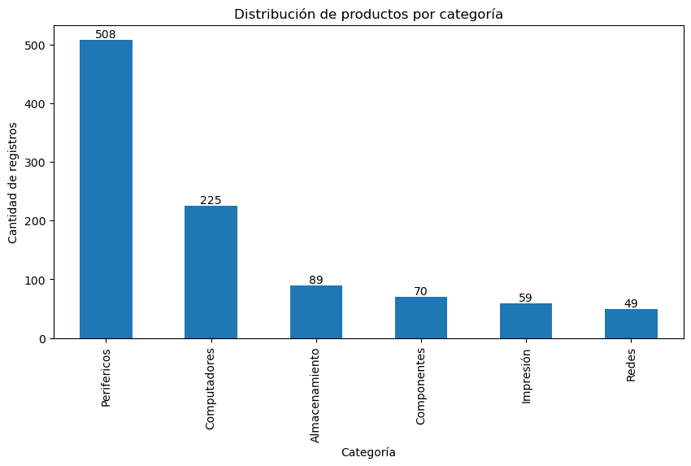

```python
conteo_categorias = df["Categoría"].value_counts()

ax = conteo_categorias.plot(
    kind="bar",
    figsize=(10, 5),
    title="Distribución de productos por categoría"
)

ax.set_xlabel("Categoría")
ax.set_ylabel("Cantidad de registros")
ax.bar_label(ax.containers[0])
```

[output not shown]

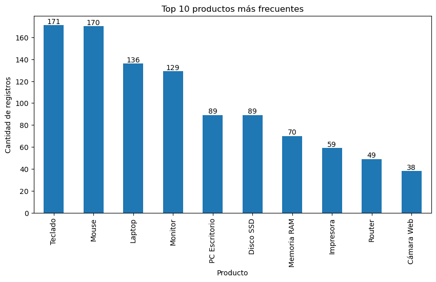

```python
top_productos = df["Producto"].value_counts().head(10)

ax = top_productos.plot(
    kind="bar",
    figsize=(10, 5),
    title="Top 10 productos más frecuentes"
)

ax.set_xlabel("Producto")
ax.set_ylabel("Cantidad de registros")
ax.bar_label(ax.containers[0])
```

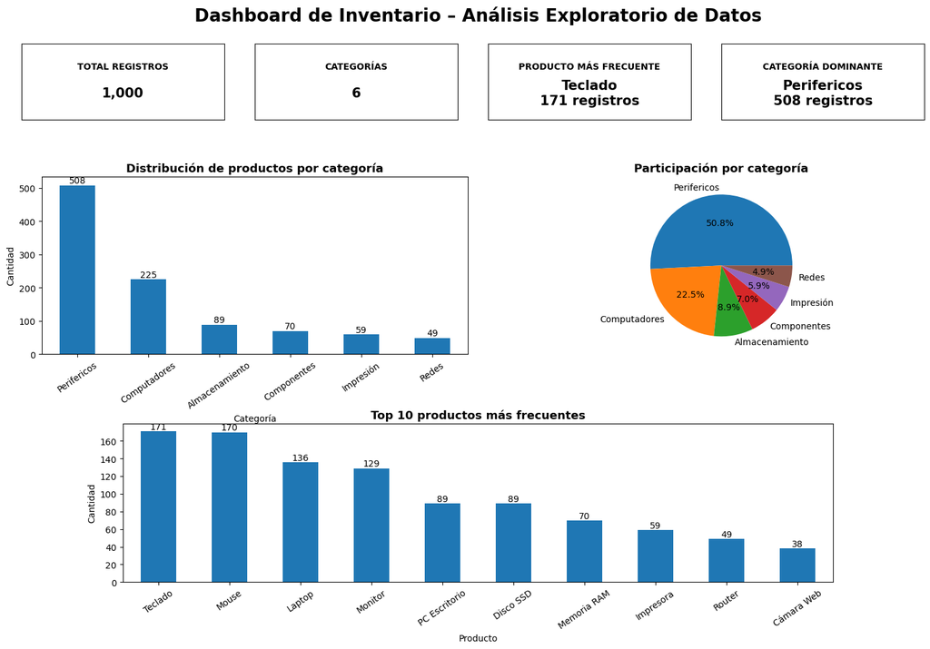

```python
import matplotlib.pyplot as plt

total_registros = len(df)

numero_categorias = df["Categoría"].nunique()

producto_top = df["Producto"].value_counts().idxmax()
cantidad_producto_top = df["Producto"].value_counts().max()

categoria_top = df["Categoría"].value_counts().idxmax()
cantidad_categoria_top = df["Categoría"].value_counts().max()

categorias = df["Categoría"].value_counts()
productos = df["Producto"].value_counts().head(10)


fig = plt.figure(figsize=(16, 10))

fig.suptitle(
    "Dashboard de Inventario – Análisis Exploratorio de Datos",
    fontsize=20,
    fontweight="bold"
)

kpis = [
    ("TOTAL REGISTROS", f"{total_registros:,}"),
    ("CATEGORÍAS", f"{numero_categorias}"),
    ("PRODUCTO MÁS FRECUENTE", f"{producto_top}\n{cantidad_producto_top} registros"),
    ("CATEGORÍA DOMINANTE", f"{categoria_top}\n{cantidad_categoria_top} registros")
]

posiciones = [
    (0.05, 0.80),
    (0.28, 0.80),
    (0.51, 0.80),
    (0.74, 0.80)
]

for (titulo, valor), (x, y) in zip(kpis, posiciones):

    ax_kpi = fig.add_axes([x, y, 0.20, 0.12])

    ax_kpi.set_xticks([])
    ax_kpi.set_yticks([])

    for spine in ax_kpi.spines.values():
        spine.set_visible(True)

    ax_kpi.text(
        0.5, 0.70,
        titulo,
        ha="center",
        va="center",
        fontsize=10,
        fontweight="bold"
    )

    ax_kpi.text(
        0.5, 0.35,
        valor,
        ha="center",
        va="center",
        fontsize=15,
        fontweight="bold"
    )


ax1 = fig.add_axes([0.07, 0.43, 0.42, 0.28])

categorias.plot(
    kind="bar",
    ax=ax1
)

ax1.set_title(
    "Distribución de productos por categoría",
    fontsize=13,
    fontweight="bold"
)

ax1.set_xlabel("Categoría")
ax1.set_ylabel("Cantidad")

ax1.bar_label(ax1.containers[0])

ax1.tick_params(axis="x", rotation=35)

ax2 = fig.add_axes([0.56, 0.43, 0.36, 0.28])

categorias.plot(
    kind="pie",
    autopct="%1.1f%%",
    ax=ax2
)

ax2.set_title(
    "Participación por categoría",
    fontsize=13,
    fontweight="bold"
)

ax2.set_ylabel("")

ax3 = fig.add_axes([0.15, 0.07, 0.70, 0.25])

productos.plot(
    kind="bar",
    ax=ax3
)

ax3.set_title(
    "Top 10 productos más frecuentes",
    fontsize=13,
    fontweight="bold"
)

ax3.set_xlabel("Producto")
ax3.set_ylabel("Cantidad")

ax3.bar_label(ax3.containers[0])

ax3.tick_params(axis="x", rotation=35)


plt.savefig(
    "dashboard_inventario.png",
    dpi=300,
    bbox_inches="tight"
)
```

```python
plt.savefig(
    "dashboard_inventario.png",
    dpi=300,
    bbox_inches="tight"
)

plt.show()
```

# 5. Principales hallazgos

A partir del análisis exploratorio realizado se identificaron los siguientes hallazgos:

- La base de datos contiene **1.000 registros**.
- El conjunto de datos está compuesto por **6 categorías**.
- La categoría **Periféricos** es la más representativa, con **508 registros**, equivalentes al **50,8 %** del total.
- El producto con mayor frecuencia es **Teclado**, con **171 registros**, equivalente al **17,1 %** del total.
- La categoría Periféricos concentra más de la mitad de los registros analizados.
- No se encontraron **valores nulos** en la información.
- No se identificaron **registros duplicados**.

Estos resultados permiten identificar una concentración importante del inventario en la categoría de periféricos y proporcionan una visión general de la composición del conjunto de datos.

# 6. Conclusiones

El análisis exploratorio permitió comprender la composición y distribución del inventario a partir de 1.000 registros y 6 categorías de productos.

Los resultados muestran que **Periféricos** es la categoría con mayor participación, representando el **50,8 %** de los registros. Dentro de los productos analizados, **Teclado** y **Mouse** presentan las mayores frecuencias, con 171 y 170 registros respectivamente.

En cuanto a la calidad de los datos, no se encontraron valores nulos ni registros duplicados, lo que indica que la base de datos presenta una estructura consistente y adecuada para realizar análisis posteriores.

En conclusión, el análisis permitió transformar los datos del inventario en información útil para identificar los productos y categorías con mayor presencia. Estos resultados pueden servir como apoyo para la planificación de inventario, priorización de productos y toma de decisiones.

### Resultado final del proyecto

**Herramientas:** Python · Pandas · Matplotlib · Jupyter Notebook

**Tipo de análisis:** Análisis Exploratorio de Datos (EDA)

**Registros analizados:** 1.000

**Categorías:** 6

**Categoría dominante:** Periféricos

**Producto más frecuente:** Teclado

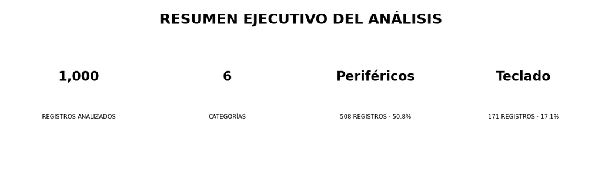

```python
import matplotlib.pyplot as plt


registros = 1000
categorias = 6
categoria_dominante = "Periféricos"
cantidad_categoria = 508
producto_mas_frecuente = "Teclado"
cantidad_producto = 171

porcentaje_categoria = cantidad_categoria / registros * 100
porcentaje_producto = cantidad_producto / registros * 100

fig, ax = plt.subplots(figsize=(13, 4))

ax.axis("off")


ax.text(
    0.5, 0.92,
    "RESUMEN EJECUTIVO DEL ANÁLISIS",
    ha="center",
    va="center",
    fontsize=22,
    fontweight="bold"
)


tarjetas = [
    (0.125, f"{registros:,}", "REGISTROS ANALIZADOS"),
    (0.375, str(categorias), "CATEGORÍAS"),
    (0.625, categoria_dominante, f"{cantidad_categoria} REGISTROS · {porcentaje_categoria:.1f}%"),
    (0.875, producto_mas_frecuente, f"{cantidad_producto} REGISTROS · {porcentaje_producto:.1f}%")
]

for x, valor, etiqueta in tarjetas:

    ax.text(
        x, 0.58,
        valor,
        ha="center",
        va="center",
        fontsize=20,
        fontweight="bold"
    )

    ax.text(
        x, 0.35,
        etiqueta,
        ha="center",
        va="center",
        fontsize=9
    )

plt.tight_layout()
plt.show()
```